# Deep Dive Spark Cyclic Barrier

## Why do we need Spark For Deep Learning

As a data scientist/ML Engineer, I want to build a **pipeline that fetches training events** from a production data warehouse and fits a DL model with data parallelism

## What are we Missing in Spark Currently ?

Complete Coordination among tasks and optimized for communication.

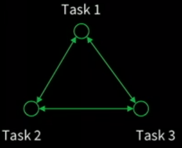

## Message Passing Interface (A Very Quick Intro)

Message Passing Interface (MPI) is a standardized and portable message-passing standard designed by a group of researchers from academia and industry to function on a wide variety of parallel computing architectures.

https://www.mpi-forum.org/

## ALL REDUCE

OPERATION which aggregates data among multiple Processes and distribute result back to them.

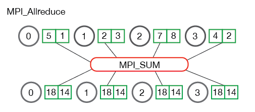

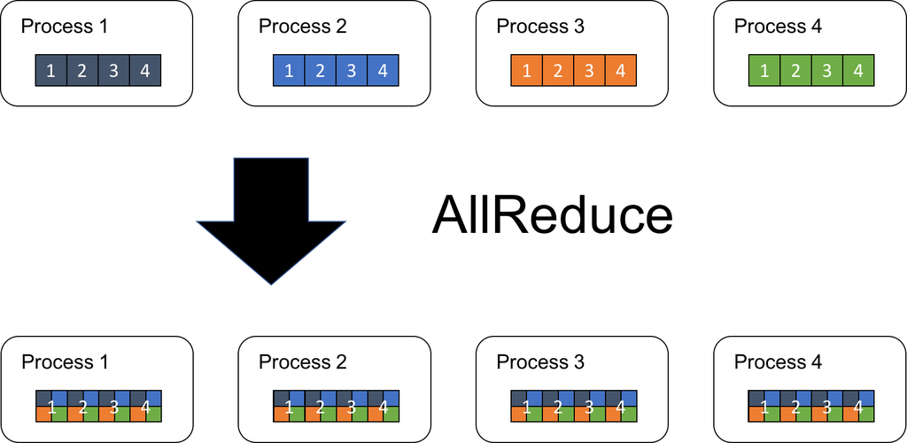

## Ring-AllReduce

Uber Horovod is based on Ring-AllReduce principle.

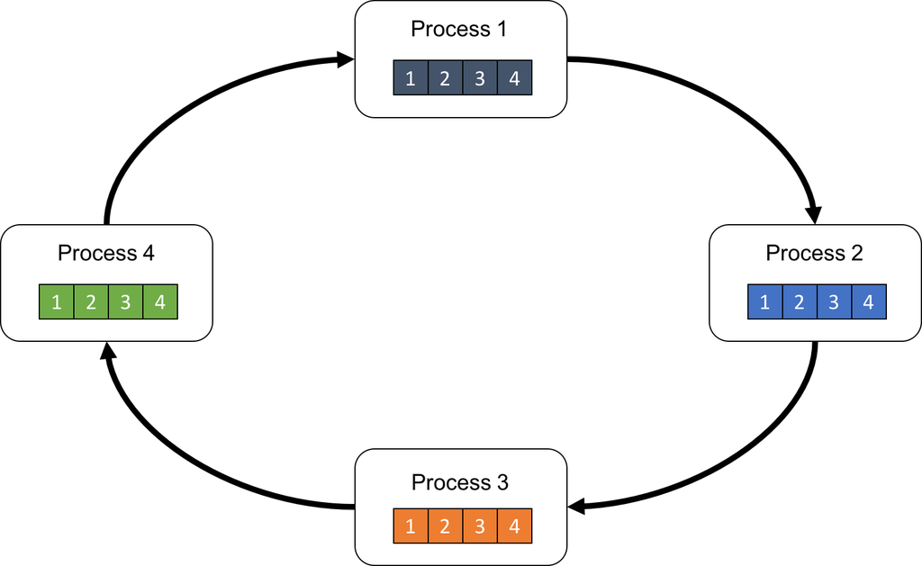

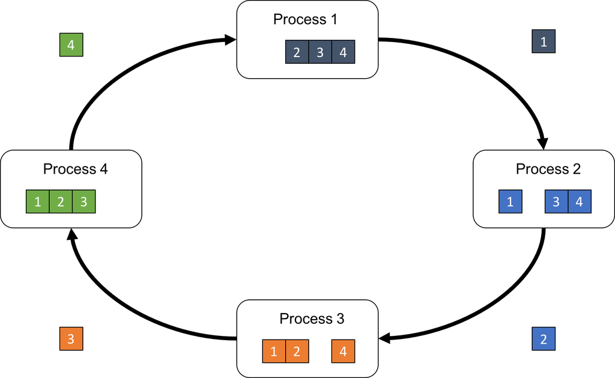

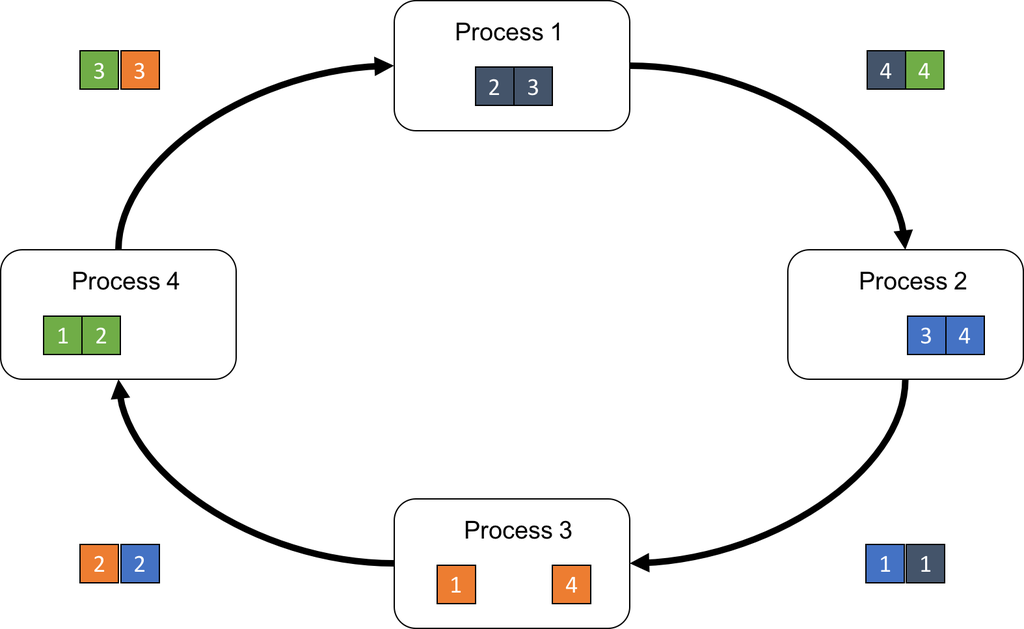

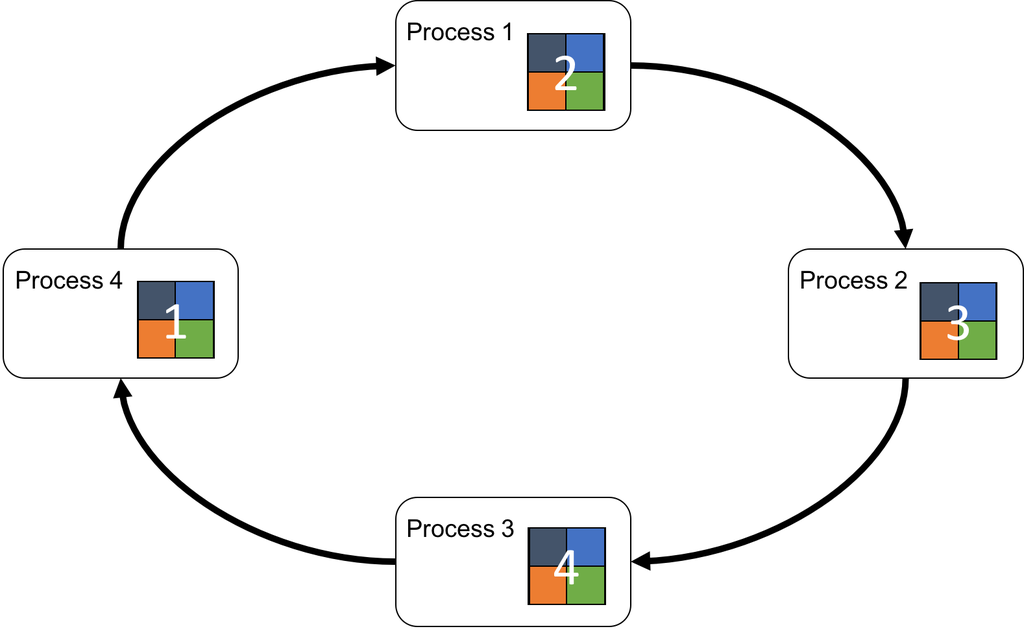

## Dense Tensor

This is used to average Dense Tensors

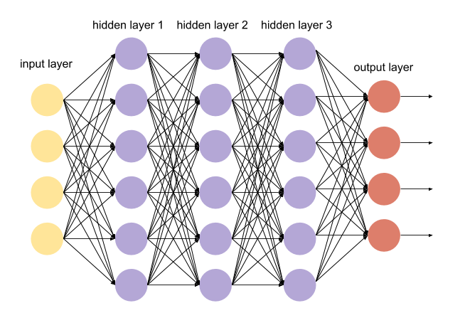

## Broadcast

Operation that broadcasts data from one process, onto all other process.

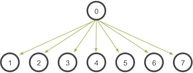

## ALL GATHER

Operation that gathers data from all processes on every process.

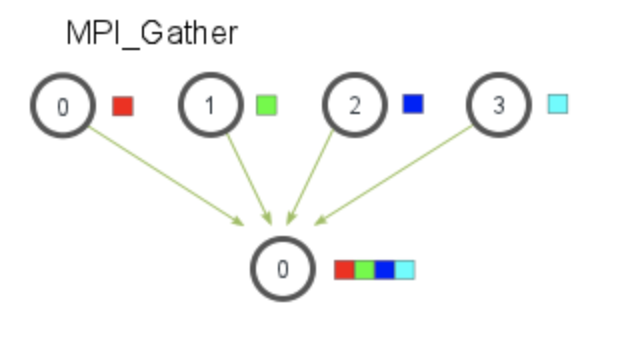

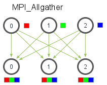

This is used to collect values of Sparse Tensors

## Spark Gang Scheduling

- In Spark, a task in a stage doesn’t depend on any other tasks in the same stage, and hence it can be scheduled independently But

  In MPI, all workers start at the same time and pass messages around
- Spark can also provide an extra layer of **fault tolerance** in case some tasks failed in the middle, where Spark would abort all tasks and restart the stage.

## Spark Barrier Schedule Features 2.4 ++ 3.0

- Launch tasks at the same time for a stage and provide sufficient info and tooling for users to embed distributed DL training workload.
- Handle failure scenarios properly.
- Barrier execution mode able to integrate with Standalone cluster manager.
- User can set up MPI in barrier stage with external cluster manager (YARN/Mesos/K8s)
- Scala/Python Support for Now -> No R

## THE ARCHITECTURE

LETS GO LITTLE DEEP

[figure not shown]

## Barrier Stage

Does not launch any of its tasks unless enough resources are not available to launch all the tasks at the same time.

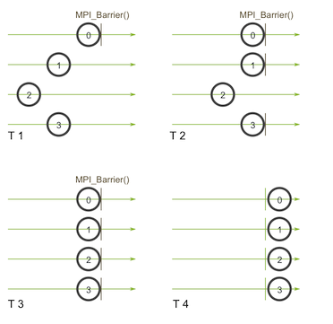

Not Enough Free CPU Cores

Always Retry WHOLE STAGE, if any Task(s) Fail !!!

[figure not shown]

## Schedule Barrier Tasks

Spark TaskScheduler schedules Pending Tasks on available Slots by availability so All tasks in same stage don’t get launched at the Same Time.

## Time Based Weight Approach

Taskset pending for long time will be assigned for highest priority weight to be scheduled. This avoids Taskset blocked FOREVER

[figure not shown]

## Task Barrier

Allows Users to insert SYNC in the middle of Task Execution, helps coordinate tasks within a barrier stage

MPI BARRIER

## Task Failure/Fault Tolerance

To ensure correctness, a barrier stage always RESTART THE WHOLE STAGE when any task(s) fail.

But it has nothing to do with Windows Restart …

[figure not shown]

## Speculative Task

As it will Launch all tasks in a Barrier Stage as the Same Time, there is no need to launch a Speculative task for a Barrier Stage Taskset

## All OR Nothing Gang Scheduling

All or Nothing Approach, so any Spark task where it runs only a subset of all the partitions , will create trouble for Barrier Scheduling.

The above issues are all related to the issue that ancestor RDDs have different number of partitions from the resulting RDD (eg. union/coalesce/first/take/PartitionPruningRDD

## Spark Hydrogen Project

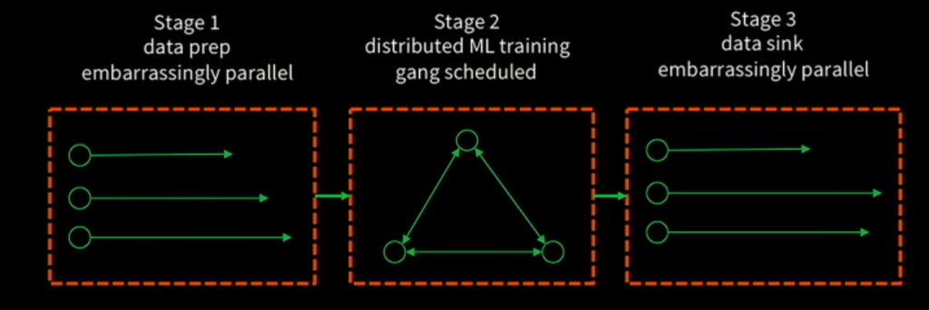

## SHOW ME THE CODE

## Local Cluster SetUp

```
    val spark = SparkSession.builder()
      .appName("Multiple Barriers Available")
      .master("local[4]")
      .config("spark.scheduler.barrier.maxConcurrentTasksCheck.maxFailures", "5")
      .config("spark.scheduler.barrier.maxConcurrentTasksCheck.interval", "1s")
     .config("spark.barrier.sync.timeout", "2")
      .getOrCreate()

    val inputRDD = spark.sparkContext.makeRDD(1 to 10, 4)
```

## All Good

```
   inputRDD.barrier().mapPartitions(_ => {
      val context = BarrierTaskContext.get()
      Thread.sleep(Random.nextInt(1000))
      context.barrier()
      val time1 = System.currentTimeMillis()
      Thread.sleep(Random.nextInt(1000))
      context.barrier()
      val time2 = System.currentTimeMillis()
      Seq((time1, time2)).iterator
  }).collect()
```

## Timeout

Timeout More than Defined Sync Timeout

```
    inputRDD.barrier().mapPartitions(inp => {
      val context = BarrierTaskContext.get()
      if (context.taskAttemptId() == 3)
          Thread.sleep(3000)
      context.barrier()
      Iterator(inp.mkString(", "))
    }).collect()
```

## Spark Exception

Caused by: org.apache.spark.SparkException: The coordinator didn’t get all barrier sync requests for barrier epoch 0 from Stage 0 (Attempt 0) within 2 second(s).

## Partitions

```
  SparkSession.builder()
  .appName("Max Concurrent Barrier")
  .master("local[4]")
  .config("spark.scheduler.barrier.maxConcurrentTasksCheck.maxFailures", "5")
  .config("spark.scheduler.barrier.maxConcurrentTasksCheck.interval", "1s")
  .getOrCreate()

  val inputRDD = spark.range(20000).rdd.repartition(5)
```

## Non-Barrier Spark Partitions

Normal Mode , Runs Without Any Error

```
inputRDD.mapPartitions(numbers => {
      println(s"All numbers are ${numbers.mkString(", ")}")
      Iterator(numbers.mkString(", "))
    }).collect()
```

Barrier Mode , Error Error Error !!!

```
      inputRDD.barrier().mapPartitions(numbers => {
        println(s"All numbers are ${numbers.mkString(", ")}")
        Iterator(numbers.mkString(", "))
      }).collect()
```

## Resources < Expectations

**Error Because Number Of Partitions > Max Number of Cores**

SPARK-24819: Barrier execution mode does not allow run a barrier stage that requires more slots than the total number of slots in the cluster currently. Please init a new cluster with more CPU cores or repartition the input RDD(s) to reduce the number of slots required to run this barrier stage.

## UNBALANCED BARRIER SCHEDULER

```
    inputRDD.barrier().mapPartitions(inp => {
        val context = BarrierTaskContext.get()
        if (context.taskAttemptId() != 3) {
          context.barrier() }
        Iterator(inp.mkString(", "))
    }).collect()
```

```
  inputRDD.barrier().mapPartitions(inp => {
      val context = BarrierTaskContext.get()
      if (context.taskAttemptId() != 3) {
        context.barrier()
        context.barrier()
      } else {
        context.barrier()
      }
      Iterator(inp.mkString(", "))
  }).collect()
```

Caused by: org.apache.spark.SparkException: The coordinator didn’t get all barrier sync requests for barrier epoch 1 from Stage 0 (Attempt 0) within 2 second(s).

[output not shown]

## PartitionPruningRDD

```
    master("local[4]")
    .config("spark.scheduler.barrier.maxConcurrentTasksCheck.maxFailures", "5")
    .config("spark.scheduler.barrier.maxConcurrentTasksCheck.interval", "1s")
    .config("spark.barrier.sync.timeout", "2")
    val inputRDD = spark.sparkContext.makeRDD(1 to 20, 4)
    val pruneRDD = new PartitionPruningRDD(inputRDD, index => index > 2)
```

```
      prunedRDD.barrier().mapPartitions(each => {
        Iterator(each.mkString(","))
      }).collect()
```

```
      //Shuffled Map Stage on Prune RDD (Error)
      prunedRDD.barrier()
      .mapPartitions(each => {
        Iterator(each.mkString(","))
      }).repartition(2)
      .collect()
```

```
      //PruneRDD to RDD (No Error)
      prunedRDD.repartition(2)
      .barrier().mapPartitions(each => {
          Iterator(each.mkString(","))
        }).collect()
```

## Unsupported RDD Chain Exception

[SPARK-24820][SPARK-24821]: Barrier execution mode does not allow the following pattern of RDD chain within a barrier stage:

1. Ancestor RDDs that have different number of partitions from the resulting RDD (eg. union/coalesce/first/take/PartitionPruningRDD). A workaround for first/take can be barrierRdd.collect.head (scala) or barrierRdd.collect()[0] (python).
2. An RDD that depends on multiple barrier RDDs (eg. barrierRdd1.zip(barrierRdd2)).

## Barriers on Partial Partitions is No GOOD

Executing Process Only when Partitions in {1,3}

```
  spark.sparkContext.submitJob(
    rdd = inputRDD.barrier().mapPartitions(numbers => {terator(numbers)}),
    processPartition = (iter: Iterator[Iterator[Int]]) => iter.toArray,
    partitions = Seq(1, 3),
    resultHandler = {
      case (_, _) => return
    }: (Int, Array[Iterator[Int]]) => Unit,
    resultFunc = { return})
```

Without Barrier Partitions, above will work absolutely fine !!!

## Error and Non Error Barrier

```
  // Union Barrier RDD
  val barrierRDD = spark.sparkContext.makeRDD(1 to 10, 2).barrier().mapPartitions(each => each)
  val normalRDD = spark.sparkContext.makeRDD(1 to 10, 2)
  barrierRDD.union(normalRDD).map(each => each + 1).collect()

  // Coalescing Barrier RDD
  val coalesceRDD = inputRDD.barrier().mapPartitions(each => each).coalesce(1)
  coalesceRDD.map(each => each + 1).collect()

  // Zipping Barrier RDDsß
  val barrierRDD1 = inputRDD.barrier().mapPartitions(each => each)
  val barrierRDD2 = spark.sparkContext.makeRDD(1 to 10, 4).barrier().mapPartitions(each => each)
  barrierRDD1.zip(barrierRDD2).map(x => x._1 + x._2).collect()

  // No Error as No Shuffling
  val barrierRDD = inputRDD.barrier().mapPartitions(each => each)
  barrierRDD.zip(inputRDD).map(x => x._1 + x._2).collect()
```